# Leonard, Lee, & Schultz 2017

## Purpose

Discuss:

Leonard, J. A., Lee, Y., & Schulz, L. E. (2017). Infants make more attempts to achieve a goal when they see adults persist. *Science*, *357*(6357), 1290–1294. Retrieved from http://dx.doi.org/10.1126/science.aan2317.

## Video exemplar

(tried to embed, but this only works sporadically.)

http://science.sciencemag.org/highwire/filestream/699641/field_highwire_adjunct_files/1/aan2317s1.mp4

## Figures

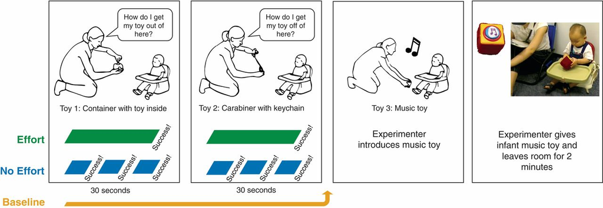

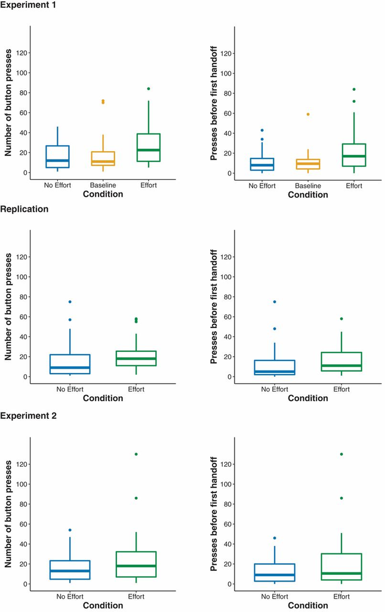

## Methods info from [supplementary materials](http://science.sciencemag.org/content/sci/suppl/2017/09/20/357.6357.1290.DC1/aan2317_Leonard_SM.pdf)

> “Button presses were operationalized as a hand pushing down the button. Button presses were coded from videotape by two coders blind to hypotheses and condition (inter-rater reliability $r = .99, p < .001$). Data from a single coder was used for analyses but all results held with the second coder’s data. Coders agreed with the experimenter’s judgment on the termination of the experiment 100% of the time.”

(Supplement, p. 2)

> “Additionally, a coder blind to condition and hypotheses coded the tapes for potential confounds. No difference was found across the conditions for whether the parent talked to the child ($\chi^2 (2, N=102)=1.03$, $p = .60$), parents’ proximity to the infant (as distance in inches, $H(2) = 4.32$, $p = .12$), and parents’ encouragement to the infant ($\chi^2 (2, N = 102) = 5.56$, $p = .06$). Additionally, because the experimenter might have conveyed more enthusiasm in handing the toy to the child in the Effort than the No Effort condition, a second coder rated the experimenter’s enthusiasm at the start of the test trial on a Likert scale, blind to conditions ($W = 525$, $p = .50$).”

(Supplement, p. 2)

## Questions, cheers, & lamentations

### Questions

- Could ‘effort’ be based on personal qualities of child?
- Differences in environment (noise, what parent did, etc.)?
- What do parents & siblings do (for work, at home)?
- Would parent as demonstrator elicit stronger responses from kid?
- How does child’s attention span affect outcome?
- Individual differences in child’s interest in the toy?

### Cheers

- Preregistration of replication
- Show video exemplars
- Shared [data and analysis scripts](https://osf.io/xjz8e/).

## Lamentations

- Plots don’t show individual responses (but we could fix with data file)
- Focus only on button pressing, lots of other behaviors that might have distinguished groups
- Could share videos of all participants on Databrary so other researchers could follow up
- *Science* article space limitations causes important details to be ‘buried’ in teh supplementary materials